# **DAT 402 Project 2**

# **DeFungi: The Dataset**

## **Dataset Overview:**

**Source**: [Kaggle Data Source](https://urldefense.com/v3/__https://archive.ics.uci.edu/dataset/773/defungi__;!!IKRxdwAv5BmarQ!bq4Lu8RB23DtElwqy-ofh2Jf38t8PD7ImiDXfNUU58o-d1GD39hEdle3_F7brgN6qhZohhKx59nnnfUS4wU$)

DeFungi is a dataset designed for the direct mycological examination of microscopic fungi images sourced from superficial fungal infections caused by yeasts, molds, or dermatophyte fungi. The images have been manually labeled into five distinct classes with the assistance of subject matter experts. Additionally, automated algorithms have cropped the images to produce the final dataset.

- **Total Images**: Over 9,114 images
- **Total Size**: Approximately 150 MB
- **Number of Classes**: 5 classes

## **Objective:**

Train the data with appropriate algorithms to maximize accuracy and precision in classifying the images.

## **Methodology:**

1. **Data Extraction**: Extract essential information from all images and arrange them into a structured dataset for exploration.
2. **Dimensionality Reduction**: Apply PCA to the dataset to reduce dimensionality.
3. **Model Training**: Train both the original dataset and the reduced dataset from PCA to determine which performs better.
4. **Model Comparison**: Compare the results of different models and draw conclusions.

## **Import the Packages**

```python
import os
import cv2
import warnings
import numpy as np
from pathlib import Path
from skimage.feature import graycomatrix, graycoprops
from skimage.feature import local_binary_pattern
from sklearn.model_selection import train_test_split, cross_val_score, KFold
from sklearn.preprocessing import StandardScaler
from sklearn.model_selection import train_test_split
from sklearn.cluster import KMeans
from sklearn.decomposition import PCA
from sklearn.metrics import accuracy_score, precision_score, recall_score, f1_score, confusion_matrix, ConfusionMatrixDisplay
from sklearn.ensemble import RandomForestClassifier
from sklearn.mixture import GaussianMixture
from sklearn.neural_network import MLPClassifier
from sklearn.metrics import roc_curve, auc
from sklearn.preprocessing import label_binarize
import matplotlib.pyplot as plt
from PIL import Image
import random
```

## **Load the Dataset**

```python
root_directory = "G:/ASU/DAT402Machine Learning for Data Science/Homework/project2/defungi"

def count_images_in_subfolders(root_dir, extensions=('.jpg', '.jpeg', '.png')):
    image_counts = {}
    try:
        root_path = Path(root_dir)
        if not root_path.exists():
            print(f"Error: Directory '{root_dir}' not found.")
            return {}
        for subdir in root_path.iterdir():
            if subdir.is_dir():
                subdir_name = subdir.name
                image_count = sum(1 for ext in extensions for _ in subdir.glob(f"*{ext}"))
                image_counts[subdir_name] = image_count
    except OSError as e:
        print(f"Error accessing directory '{root_dir}': {e}")
        return {}
    return image_counts


image_counts = count_images_in_subfolders(root_directory)

total_images = 0  # Use a different variable name to avoid shadowing the built-in sum() function
if image_counts:
    for subdir_name, count in image_counts.items():
        print(f"Subdirectory: {subdir_name}, Number of images: {count}")
        total_images += count
else:
    print("No subdirectories found or error occurred.")

print(f"Total number of images: {total_images}")
```

```
Subdirectory: H1, Number of images: 4404
Subdirectory: H2, Number of images: 2334
Subdirectory: H3, Number of images: 819
Subdirectory: H5, Number of images: 818
Subdirectory: H6, Number of images: 739
Total number of images: 9114
```

## **Feature Extraction**

**Frist, let's define functions to extract the following features.**

In total, there are 1040 features

```python
def extract_color_histogram(image, bins=8, color_space = 'hsv'):
    if color_space == 'hsv':
        hsv = cv2.cvtColor(image, cv2.COLOR_BGR2HSV)
        hist = cv2.calcHist([hsv], [0, 1, 2], None, [bins, bins, bins], [0, 180, 0, 256, 0, 256])
    elif color_space == 'lab':
        lab = cv2.cvtColor(image, cv2.COLOR_BGR2LAB)
        hist = cv2.calcHist([lab], [0, 1, 2], None, [bins, bins, bins], [0, 255, 0, 255, 0, 255])
    else:
        raise ValueError("Invalid color_space. Use 'hsv', 'lab', or 'rgb'.")
    return hist.flatten()


def extract_glcm_features(image, distances=[1], angles=[0], properties=('contrast', 'dissimilarity', 'homogeneity', 'energy', 'correlation')):
    gray = cv2.cvtColor(image, cv2.COLOR_BGR2GRAY)
    gCoMatrix = graycomatrix(gray, distances=distances, angles=angles, levels=256, symmetric=True, normed=True)
    features = []
    for prop in properties:
        features.extend(graycoprops(gCoMatrix, prop).flatten())
    return np.array(features)


def extract_lbp_features(image, P=8, R=1, method='uniform'):
    gray = cv2.cvtColor(image, cv2.COLOR_BGR2GRAY)
    lbp = local_binary_pattern(gray, P, R, method=method)
    hist, _ = np.histogram(lbp.ravel(), bins=range(0, P + 3), range=(0, P + 2))
    return hist


def calculate_average_intensity(image):
    gray = cv2.cvtColor(image, cv2.COLOR_BGR2GRAY)
    return np.mean(gray)
```

**Then, we extract these features, label them, and stardardize the dataset for further exploration.**

```python
def extract_image_features(image_path, bins=8, resize_shape=(64,64)):
    try:
        img = cv2.imread(image_path)
        if img is not None:
            img = cv2.resize(img, resize_shape)
            color_hist_hsv = extract_color_histogram(img, bins=bins, color_space='hsv')
            color_hist_lab = extract_color_histogram(img, bins=bins, color_space='lab')
            texture_features = extract_glcm_features(img)
            lbp_features = extract_lbp_features(img)
            avg_intensity = calculate_average_intensity(img)
            return np.concatenate((color_hist_hsv, color_hist_lab, texture_features, lbp_features, np.array([avg_intensity])))
        else:
            print(f"Warning: Could not load image from {image_path}. Skipping.")
            return None
    except Exception as e:
        print(f"Error processing image {image_path}: {e}")
        return None

def create_dataset(root_dir, bins=8, resize_shape=(64, 64)):
    all_features = []
    all_labels = []
    species_to_label = {}
    label_count = 0
    try:
        for i, species_dir in enumerate(Path(root_dir).iterdir()):
            if species_dir.is_dir():
                species_name = species_dir.name
                species_to_label[species_name] = label_count
                label_count += 1
                for ext in ('.jpg', '.jpeg', '.png'):
                    for image_path in species_dir.glob(f"*{ext}"):
                        features = extract_image_features(str(image_path), bins=bins, resize_shape=resize_shape)
                        if features is not None:
                            all_features.append(features)
                            all_labels.append(species_to_label[species_name])
        all_features = np.array(all_features)
        all_labels = np.array(all_labels)

        # Normalize features using StandardScaler
        scaler = StandardScaler()
        all_features = scaler.fit_transform(all_features)

        return all_features, all_labels
    except Exception as e:
        print(f"Error creating dataset: {e}")
        return None, None
```

```
Displaying images for fungi type: H1
```

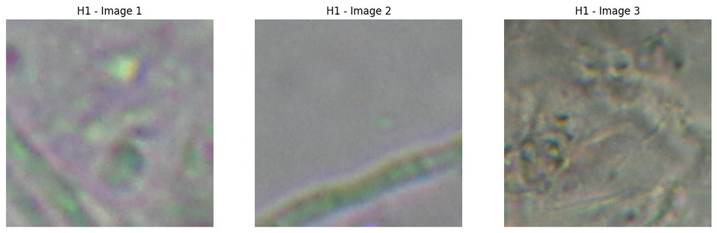

```
Displaying images for fungi type: H2
```

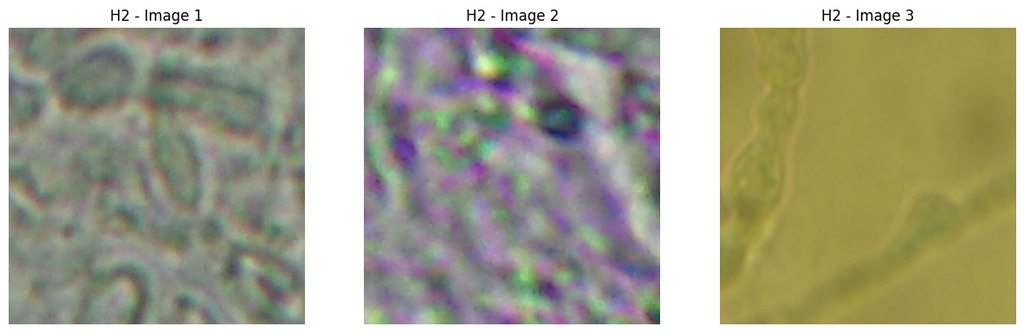

```
Displaying images for fungi type: H3
```

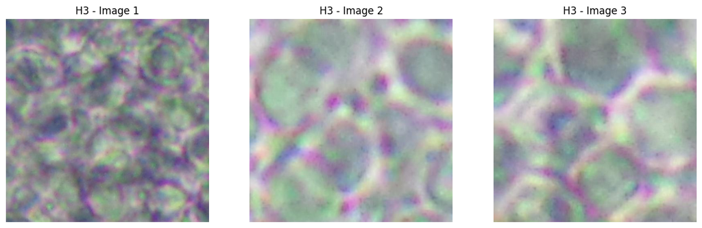

```
Displaying images for fungi type: H5
```

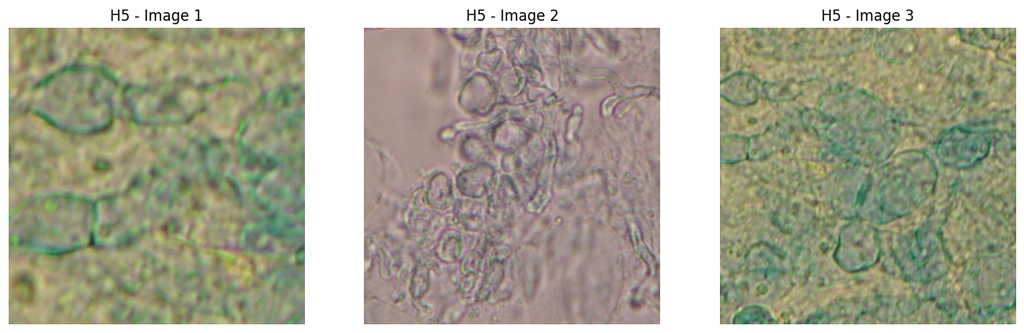

```
Displaying images for fungi type: H6
```

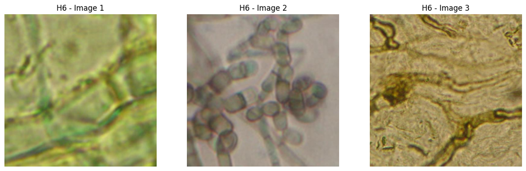

```python
def display_images_from_fungi(root_dir, num_images=3, extensions=('.jpg', '.jpeg', '.png')):
    root_path = Path(root_dir)
    try:
        if not root_path.exists():
            print(f"Error: Directory '{root_dir}' not found.")
            return

        # Loop through each fungi subfolder
        for species_dir in root_path.iterdir():
            if species_dir.is_dir():
                species_name = species_dir.name
                print(f"Displaying images for fungi type: {species_name}")

                # Collect all image paths for the current species
                images = [img for ext in extensions for img in species_dir.glob(f"*{ext}")]

                if images:
                    # Randomly select 'num_images' from the list
                    selected_images = random.sample(images, min(num_images, len(images)))

                    # Set up the plot to display images
                    plt.figure(figsize=(15, 5))
                    for i, img_path in enumerate(selected_images, 1):
                        # Open image using PIL and display it
                        img = Image.open(img_path)
                        plt.subplot(1, num_images, i)
                        plt.imshow(img)
                        plt.axis('off')
                        plt.title(f"{species_name} - Image {i}")
                    plt.show()
                else:
                    print(f"No images found in subfolder: {species_name}")
    except OSError as e:
        print(f"Error accessing directory '{root_dir}': {e}")

display_images_from_fungi(root_directory)
```

## **Explore Dataset**

*Shape of The Dataset*

```python
X, y = create_dataset(root_directory, bins=8)
print("Dataset shape:", X.shape)
```

```
Dataset shape: (9114, 1040)
```

*PCA Analysis*

- Performs PCA on the standardized dataset X
- plots the components that capture at least the specified variance threshold.
- print out the number of components and save it for future use

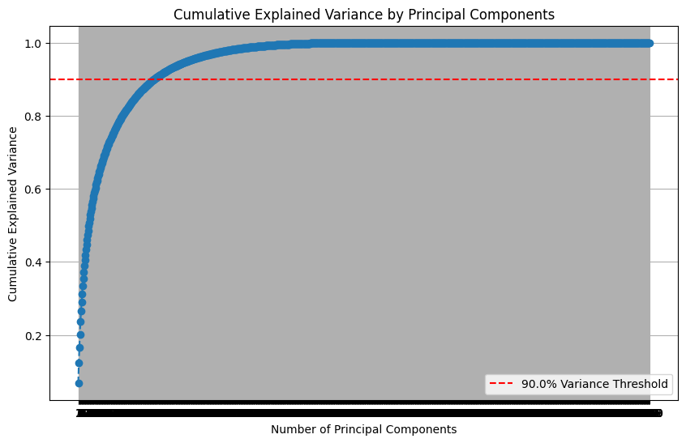

```
Number of components to retain at least 90.0% variance: 139
```

```python
variance_threshold=0.90

pca = PCA()
principal_components = pca.fit_transform(X)
explained_variance = pca.explained_variance_ratio_
cumulative_variance = np.cumsum(explained_variance)
num_components = np.argmax(cumulative_variance >= variance_threshold) + 1

# Plot the explained variance
plt.figure(figsize=(10, 6))
plt.plot(range(1, len(cumulative_variance) + 1), cumulative_variance, marker='o', linestyle='--')
plt.axhline(y=variance_threshold, color='r', linestyle='--',
            label=f'{variance_threshold * 100}% Variance Threshold')
plt.xticks(range(1, len(cumulative_variance) + 1))
plt.xlabel('Number of Principal Components')
plt.ylabel('Cumulative Explained Variance')
plt.title('Cumulative Explained Variance by Principal Components')
plt.legend()
plt.grid()
plt.show()

print(f'Number of components to retain at least {variance_threshold * 100}% variance: {num_components}')
```

## **Build Models**

Given that image data is inherently nonlinear in nature, we are going to use Random Forest and MLP algorithms respectively to build our models. To reduce dimensions, we are going to use PCA components and orginal Dataset to train the the model respectively for both algorithms, adn then compare the metrics.

1. Split Data

```python
X_train, X_test, y_train, y_test = train_test_split(X, y, test_size=0.2, random_state=42)
print("Training data shape:", X_train.shape)
print("Testing data shape:", X_test.shape)
print("Training labels shape:", y_train.shape)
print("Testing labels shape:", y_test.shape)
```

```
Training data shape: (7291, 1040)
Testing data shape: (1823, 1040)
Training labels shape: (7291,)
Testing labels shape: (1823,)
```

2. Define a function to return metrics

```python
def evaluate_model(model, X_test, y_test):
    y_pred = model.predict(X_test)

    # Calculate evaluation metrics
    accuracy = accuracy_score(y_test, y_pred)
    precision = precision_score(y_test, y_pred, average='weighted')  # Use average='weighted' for multi-class
    recall = recall_score(y_test, y_pred, average='weighted')
    f1 = f1_score(y_test, y_pred, average='weighted')

    return accuracy, precision, recall, f1
```

3. Use PCA components to train with Random Forest algorithmF We are going to print out the accuracy on training model and all metrics on testing data.

```python
pca = PCA(n_components=num_components)
X_train_pca = pca.fit_transform(X_train)
X_test_pca = pca.transform(X_test)

PCA_rf = RandomForestClassifier()
PCA_rf.fit(X_train_pca, y_train)

train_accuracy = PCA_rf.score(X_train_pca, y_train)
print(f"PCA Random Forest - Training Accuracy: {train_accuracy:.4f}")

accuracy_pca_rf, precision_pca_rf, recall_pca_rf, f1_pca_rf = evaluate_model(PCA_rf, X_test_pca, y_test)
print(f"PCA Random Forest - Accuracy: {accuracy_pca_rf:.4f}, Precision: {precision_pca_rf:.4f}, Recall: {recall_pca_rf:.4f}, F1 Score: {f1_pca_rf:.4f}")
```

```
PCA Random Forest - Training Accuracy: 1.0000
PCA Random Forest - Accuracy: 0.8629, Precision: 0.8660, Recall: 0.8629, F1 Score: 0.8589
```

4. Use original dataset to run RF

```python
rf = RandomForestClassifier()
rf.fit(X_train, y_train)


train_accuracy = rf.score(X_train, y_train)
print(f"Random Forest - Training Accuracy: {train_accuracy:.4f}")

accuracy_rf, precision_rf, recall_rf, f1_rf = evaluate_model(rf, X_test, y_test)
print(f"Random Forest - Accuracy: {accuracy_rf:.4f}, Precision: {precision_rf:.4f}, Recall: {recall_rf:.4f}, F1 Score: {f1_rf:.4f}")
```

```
Random Forest - Training Accuracy: 1.0000
Random Forest - Accuracy: 0.8623, Precision: 0.8685, Recall: 0.8623, F1 Score: 0.8575
```

**Random Forest using PCA components is only slightly better.**

5. Use PCA components to train with MLP and plot the loss and accuracy graph from 1 up to 800 epochs.

   Firstly, we define the graph function as below.

```python
def plot_mlp_training_history(losses, accuracies):
    plt.figure(figsize=(12, 5))

    # Plot loss
    plt.subplot(1, 2, 1)
    plt.plot(losses, label='Training Loss', color='blue')
    plt.title('MLP Training Loss')
    plt.xlabel('Epoch')
    plt.ylabel('Loss')
    plt.grid()
    plt.legend()

    # Plot accuracy
    plt.subplot(1, 2, 2)
    plt.plot(accuracies, label='Training Accuracy', color='green')
    plt.title('MLP Training Accuracy')
    plt.xlabel('Epoch')
    plt.ylabel('Accuracy')
    plt.grid()
    plt.legend()

    plt.tight_layout()
    plt.show()
```

```python
# Suppress warnings
warnings.filterwarnings("ignore")


pca = PCA(n_components=num_components)
X_train_pca = pca.fit_transform(X_train)

train_losses = []
train_accuracies = []


mlp_model = MLPClassifier(random_state=42, max_iter=1, warm_start=True)

n_epochs = 800
for epoch in range(n_epochs):
    mlp_model.fit(X_train_pca, y_train)
    train_loss = mlp_model.loss_
    train_accuracy = mlp_model.score(X_train_pca, y_train)

    train_losses.append(train_loss)
    train_accuracies.append(train_accuracy)

best_epoch = np.argmax(train_accuracies)  # Find the index of the max training accuracy
print(f"Best epoch for training accuracy: {best_epoch} with accuracy: {train_accuracies[best_epoch]:.4f}")
```

```
Best epoch for training accuracy: 777 with accuracy: 0.9971
```

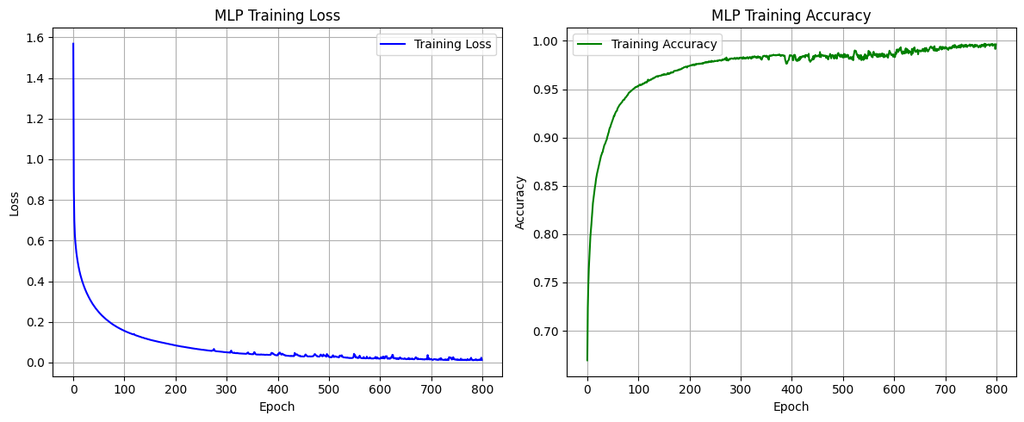

```python
plot_mlp_training_history(train_losses, train_accuracies)
```

We use best_epoch + 1 for fitting up to that epoch

```python
pca_best_mlp_model = MLPClassifier(random_state=42, max_iter=best_epoch + 1)
pca_best_mlp_model.fit(X_train_pca, y_train)

accuracy_pca_best_mlp, precision_pca_best_mlp, recall_pca_best_mlp, f1_pca_best_mlp = evaluate_model(pca_best_mlp_model, X_test_pca, y_test)
print(f"pca_best_mlp_model - Accuracy: {accuracy_pca_best_mlp:.4f}, Precision: {precision_pca_best_mlp:.4f}, Recall: {recall_pca_best_mlp:.4f}, F1 Score: {f1_pca_best_mlp:.4f}")
```

```
pca_best_mlp_model - Accuracy: 0.7493, Precision: 0.7539, Recall: 0.7493, F1 Score: 0.7509
```

6. Now we use the original dataset to run with MLP

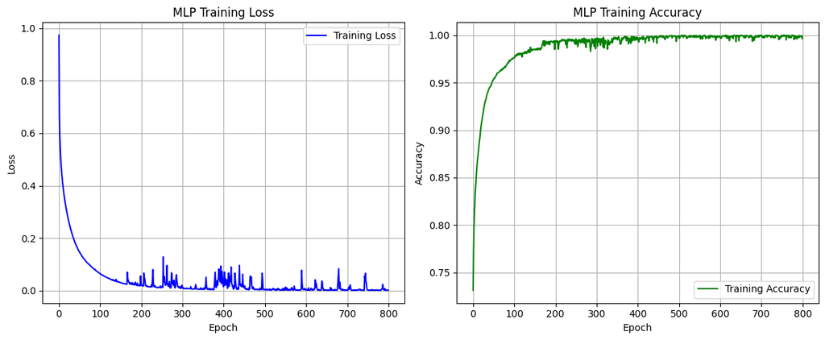

```
Best epoch for training accuracy: 562 with accuracy: 1.0000
best_mlp_model - Accuracy: 0.8826, Precision: 0.8818, Recall: 0.8826, F1 Score: 0.8817
```

```python
warnings.filterwarnings("ignore")

train_losses = []
train_accuracies = []

mlp_model = MLPClassifier(random_state=42, max_iter=1, warm_start=True)

n_epochs = 800
for epoch in range(n_epochs):
    mlp_model.fit(X_train, y_train)

    train_loss = mlp_model.loss_
    train_accuracy = mlp_model.score(X_train, y_train)

    train_losses.append(train_loss)
    train_accuracies.append(train_accuracy)

plot_mlp_training_history(train_losses, train_accuracies)

best_epoch = np.argmax(train_accuracies)
best_mlp_model = MLPClassifier(random_state=42, max_iter=best_epoch + 1)
best_mlp_model.fit(X_train, y_train)

print(f"Best epoch for training accuracy: {best_epoch} with accuracy: {train_accuracies[best_epoch]:.4f}")
accuracy_best_mlp, precision_best_mlp, recall_best_mlp, f1_best_mlp = evaluate_model(best_mlp_model, X_test, y_test)
print(f"best_mlp_model - Accuracy: {accuracy_best_mlp:.4f}, Precision: {precision_best_mlp:.4f}, Recall: {recall_best_mlp:.4f}, F1 Score: {f1_best_mlp:.4f}")
```

Apparently, MLP with the original data performs much better. We are going to choose the Random Forest with PCA components and MLP with orignal dataset for metric comparison.

# **Model Comparison**

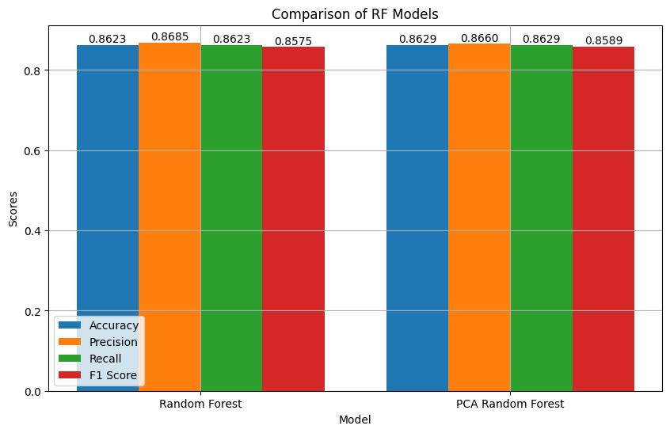

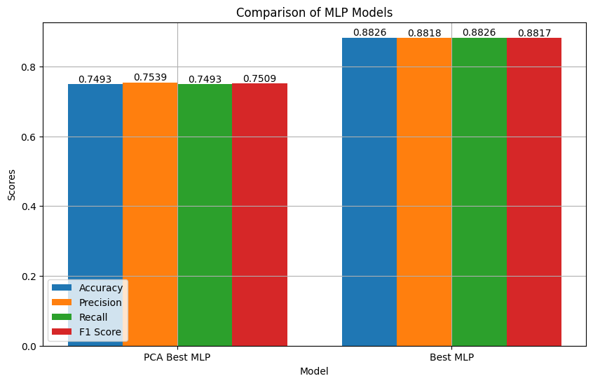

```python
mlp_models = [
    ('PCA Best MLP', pca_best_mlp_model),
    ('Best MLP', best_mlp_model)
]
rf_models = [
    ('Random Forest', rf),
    ('PCA Random Forest', PCA_rf)
]

mlp_metrics = [
    (accuracy_pca_best_mlp, precision_pca_best_mlp, recall_pca_best_mlp, f1_pca_best_mlp),
    (accuracy_best_mlp, precision_best_mlp, recall_best_mlp, f1_best_mlp)
]
rf_metrics = [
    (accuracy_rf, precision_rf, recall_rf, f1_rf),
    (accuracy_pca_rf, precision_pca_rf, recall_pca_rf, f1_pca_rf)
]

def compare_models(models, metrics, title="Model Comparison"):
    model_names = []
    accuracies = []
    precisions = []
    recalls = []
    f1_scores = []

    for (model_name, _), (accuracy, precision, recall, f1) in zip(models, metrics):
        model_names.append(model_name)
        accuracies.append(accuracy)
        precisions.append(precision)
        recalls.append(recall)
        f1_scores.append(f1)

    bar_width = 0.2
    index = np.arange(len(models))

    plt.figure(figsize=(10, 6))
    bar_accuracy = plt.bar(index, accuracies, bar_width, label='Accuracy')
    bar_precision = plt.bar(index + bar_width, precisions, bar_width, label='Precision')
    bar_recall = plt.bar(index + 2 * bar_width, recalls, bar_width, label='Recall')
    bar_f1 = plt.bar(index + 3 * bar_width, f1_scores, bar_width, label='F1 Score')

    plt.xlabel('Model')
    plt.ylabel('Scores')
    plt.title(title)
    plt.xticks(index + bar_width * 1.5, model_names)
    plt.legend()
    plt.grid(True)

    for bars, metrics in zip([bar_accuracy, bar_precision, bar_recall, bar_f1],
                             [accuracies, precisions, recalls, f1_scores]):
        for bar, metric in zip(bars, metrics):
            height = bar.get_height()
            plt.text(bar.get_x() + bar.get_width() / 2, height, f'{metric:.4f}',
                     ha='center', va='bottom')
    plt.show()

compare_models(rf_models, rf_metrics, title="Comparison of RF Models")
compare_models(mlp_models, mlp_metrics, title="Comparison of MLP Models")
```

## Confusion Matrix

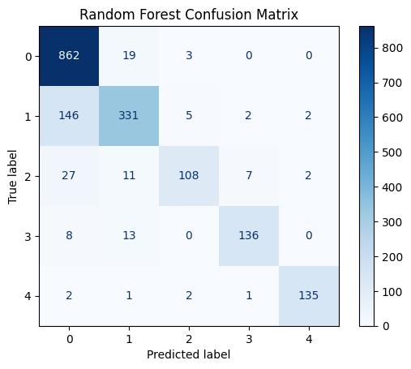

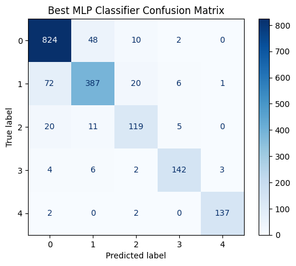

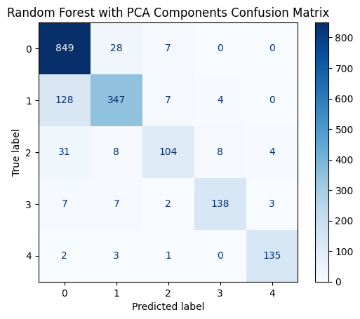

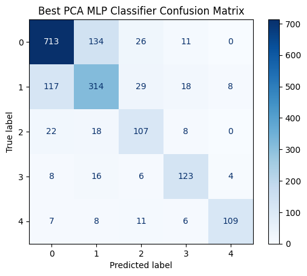

```python
def plot_confusion_matrix(model, X_test, y_test, title):
    y_pred = model.predict(X_test)
    cm = confusion_matrix(y_test, y_pred)
    disp = ConfusionMatrixDisplay(confusion_matrix=cm)
    disp.plot(cmap=plt.cm.Blues)
    plt.title(title)
    plt.show()

plot_confusion_matrix(rf, X_test, y_test, title="Random Forest Confusion Matrix")
plot_confusion_matrix(best_mlp_model, X_test, y_test, title="Best MLP Classifier Confusion Matrix")
plot_confusion_matrix(PCA_rf, X_test_pca, y_test, title="Random Forest with PCA Components Confusion Matrix")
plot_confusion_matrix(pca_best_mlp_model, X_test_pca, y_test, title="Best PCA MLP Classifier Confusion Matrix")
```

## Receiver Operative Characteristic (ROC) Curve

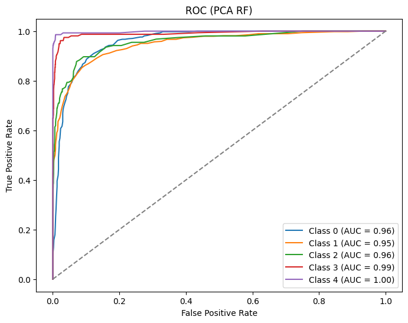

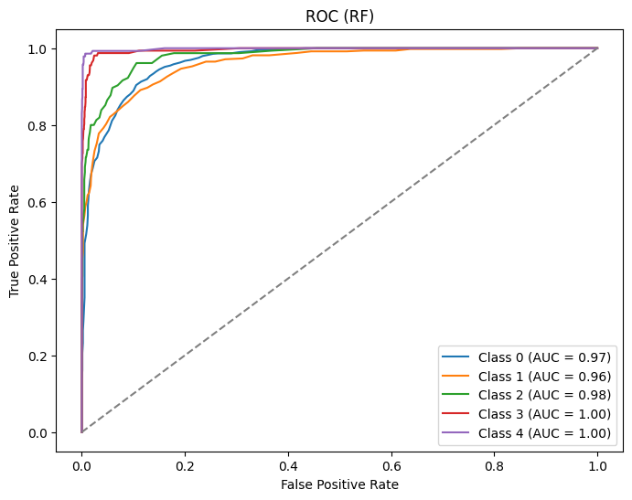

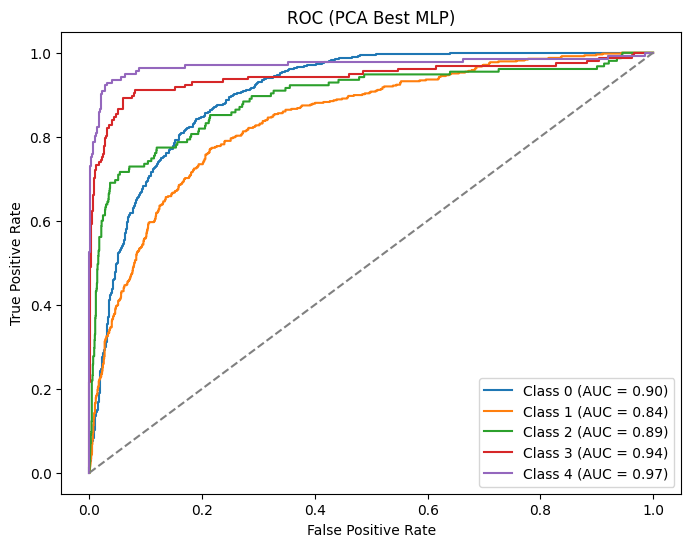

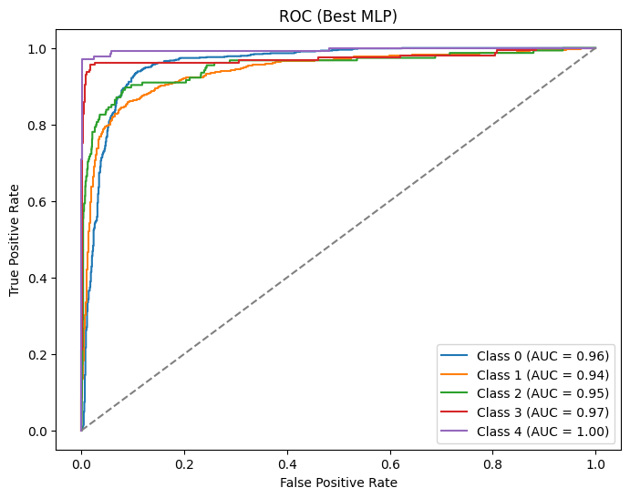

```python
def plot_roc_curve_multi_class(model, X_test, y_test, n_classes, title = "Model Name"):

    y_pred_prob = model.predict_proba(X_test)

    y_test_bin = label_binarize(y_test, classes=[0, 1, 2, 3, 4])

    plt.figure(figsize=(8, 6))
    for i in range(n_classes):
        fpr, tpr, _ = roc_curve(y_test_bin[:, i], y_pred_prob[:, i])
        roc_auc = auc(fpr, tpr)
        plt.plot(fpr, tpr, label=f'Class {i} (AUC = {roc_auc:.2f})')

    plt.plot([0, 1], [0, 1], color='gray', linestyle='--')
    plt.xlabel('False Positive Rate')
    plt.ylabel('True Positive Rate')
    plt.title(title)
    plt.legend(loc='lower right')
    plt.show()

plot_roc_curve_multi_class(PCA_rf, X_test_pca, y_test, n_classes=5, title = "ROC (PCA RF)")
plot_roc_curve_multi_class(rf, X_test, y_test, n_classes=5, title = "ROC (RF)")
plot_roc_curve_multi_class(pca_best_mlp_model, X_test_pca, y_test, n_classes=5,title =  "ROC (PCA Best MLP)")
plot_roc_curve_multi_class(best_mlp_model, X_test, y_test, n_classes=5, title = "ROC (Best MLP)")
```